# Linear Regression: Rising Tuition Costs

## Introduction

This project is investigating the average cost of college by year. The data used in this project is publicly available [here.](https://educationdata.org/average-cost-of-college-by-year)

## Libraries

This linear regression was created using the ordinary least squares (OLS) method and the StatsModels model package.

```python
import pandas as pd
import numpy as np
from matplotlib import pyplot as plt
import statsmodels.api as sm
```

## Import Data

This code is importing the data and displaying the first five rows of the dataset.

```python
b = pd.read_csv('C:/Users/Kelly Nickelson/Desktop/UniversityTuition.csv')
b.head()
```

|  | Year | Tuition |
| --- | --- | --- |
| 0 | 2019 | 9349 |
| 1 | 2018 | 9212 |
| 2 | 2017 | 9036 |
| 3 | 2016 | 8804 |
| 4 | 2015 | 8778 |

## Simple Linear Regression

The simple linear regression coefficents are estimated using the least squares criteria. Meaning, we are finding the line that minimizes the sum of squared residuals, or sum of the squared errors. This code estimates the model coeffcients for the college tution data.

```python
X = b['Year']
Y = b['Tuition']
model = sm.OLS(Y, X).fit()
predictions = model.predict(X)
print_model = model.summary()
print(print_model)
```

```
                                 OLS Regression Results
=======================================================================================
Dep. Variable:                Tuition   R-squared (uncentered):                   0.573
Model:                            OLS   Adj. R-squared (uncentered):              0.565
Method:                 Least Squares   F-statistic:                              71.04
Date:                Wed, 09 Mar 2022   Prob (F-statistic):                    2.33e-11
Time:                        19:27:18   Log-Likelihood:                         -507.88
No. Observations:                  54   AIC:                                      1018.
Df Residuals:                      53   BIC:                                      1020.
Df Model:                           1
Covariance Type:            nonrobust
==============================================================================
                 coef    std err          t      P>|t|      [0.025      0.975]
------------------------------------------------------------------------------
Year           1.7083      0.203      8.428      0.000       1.302       2.115
==============================================================================
Omnibus:                        8.363   Durbin-Watson:                   0.005
Prob(Omnibus):                  0.015   Jarque-Bera (JB):                6.765
Skew:                           0.759   Prob(JB):                       0.0340
Kurtosis:                       2.161   Cond. No.                         1.00
==============================================================================

Notes:
[1] R² is computed without centering (uncentered) since the model does not contain a constant.
[2] Standard Errors assume that the covariance matrix of the errors is correctly specified.
```

The R-squared shown above is possibly the most important measurement produced in the summary table. R-squared indicates that our model explains 57% of the change in our 'Tuition' variable.

## Model Visualization

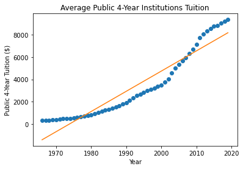

```python
import matplotlib.pyplot as plt

#create basic scatterplot
plt.plot(X, Y, 'o')
plt.title("Average Public 4-Year Institutions Tuition")
plt.xlabel("Year")
plt.ylabel("Public 4-Year Tuition ($)")

#obtain m (slope) and b(intercept) of linear regression line
m, b = np.polyfit(X, Y, 1)

#add linear regression line to scatterplot
plt.plot(X, m*X+b)
```